# Google Cyclistic Capstone Project

Seth

19/11/2021

## Install packages needed

```r
install.packages("tidyverse")
install.packages("lubridate")
install.packages("ggplot")
install.packages("lessR")
```

## Load packages

```r
library(tidyverse)
library(lubridate)
library(ggplot2)
library(dplyr)
library(lessR)
```

## Import the Data/check data for inconsistencies/ wrangle data

```r
april_2020 <- read_csv("Case Study/Data/Cyclistic_Trip_Data_202004.csv")
may_2020 <- read_csv("Case Study/Data/Cyclistic_Trip_Data_202005.csv")
june_2020 <- read_csv("Case Study/Data/Cyclistic_Trip_Data_202006.csv")
july_2020 <- read_csv("Case Study/Data/Cyclistic_Trip_Data_202007.csv")
august_2020 <- read_csv("Case Study/Data/Cyclistic_Trip_Data_202008.csv")
september_2020 <- read_csv("Case Study/Data/Cyclistic_Trip_Data_202009.csv")
october_2020 <- read_csv("Case Study/Data/Cyclistic_Trip_Data_202010.csv")
november_2020 <- read_csv("Case Study/Data/Cyclistic_Trip_Data_202011.csv")
december_2020 <- read_csv("Case Study/Data/Cyclistic_Trip_Data_202012.csv")
january_2021 <- read_csv("Case Study/Data/Cyclistic_Trip_Data_202101.csv")
february_2021 <- read_csv("Case Study/Data/Cyclistic_Trip_Data_202102.csv")
march_2021 <- read_csv("Case Study/Data/Cyclistic_Trip_Data_202103.csv")
```

```r
colnames(april_2020)
```

```
##  [1] "ride_id"            "rideable_type"      "started_at"         "ended_at"           "start_station_name" "start_station_id"   "end_station_name"
##  [8] "end_station_id"     "start_lat"          "start_lng"          "end_lat"            "end_lng"            "member_casual"
```

```r
colnames(may_2020)
```

```
##  [1] "ride_id"            "rideable_type"      "started_at"         "ended_at"           "start_station_name" "start_station_id"   "end_station_name"
##  [8] "end_station_id"     "start_lat"          "start_lng"          "end_lat"            "end_lng"            "member_casual"
```

```r
colnames(june_2020)
```

```
##  [1] "ride_id"            "rideable_type"      "started_at"         "ended_at"           "start_station_name" "start_station_id"   "end_station_name"
##  [8] "end_station_id"     "start_lat"          "start_lng"          "end_lat"            "end_lng"            "member_casual"
```

```r
colnames(july_2020)
```

```
##  [1] "ride_id"            "rideable_type"      "started_at"         "ended_at"           "start_station_name" "start_station_id"   "end_station_name"
##  [8] "end_station_id"     "start_lat"          "start_lng"          "end_lat"            "end_lng"            "member_casual"
```

```r
colnames(august_2020)
```

```
##  [1] "ride_id"            "rideable_type"      "started_at"         "ended_at"           "start_station_name" "start_station_id"   "end_station_name"
##  [8] "end_station_id"     "start_lat"          "start_lng"          "end_lat"            "end_lng"            "member_casual"
```

```r
colnames(september_2020)
```

```
##  [1] "ride_id"            "rideable_type"      "started_at"         "ended_at"           "start_station_name" "start_station_id"   "end_station_name"
##  [8] "end_station_id"     "start_lat"          "start_lng"          "end_lat"            "end_lng"            "member_casual"
```

```r
colnames(october_2020)
```

```
##  [1] "ride_id"            "rideable_type"      "started_at"         "ended_at"           "start_station_name" "start_station_id"   "end_station_name"
##  [8] "end_station_id"     "start_lat"          "start_lng"          "end_lat"            "end_lng"            "member_casual"
```

```r
colnames(november_2020)
```

```
##  [1] "ride_id"            "rideable_type"      "started_at"         "ended_at"           "start_station_name" "start_station_id"   "end_station_name"
##  [8] "end_station_id"     "start_lat"          "start_lng"          "end_lat"            "end_lng"            "member_casual"
```

```r
colnames(december_2020)
```

```
##  [1] "ride_id"            "rideable_type"      "started_at"         "ended_at"           "start_station_name" "start_station_id"   "end_station_name"
##  [8] "end_station_id"     "start_lat"          "start_lng"          "end_lat"            "end_lng"            "member_casual"
```

```r
colnames(january_2021)
```

```
##  [1] "ride_id"            "rideable_type"      "started_at"         "ended_at"           "start_station_name" "start_station_id"   "end_station_name"
##  [8] "end_station_id"     "start_lat"          "start_lng"          "end_lat"            "end_lng"            "member_casual"
```

```r
colnames(february_2021)
```

```
##  [1] "ride_id"            "rideable_type"      "started_at"         "ended_at"           "start_station_name" "start_station_id"   "end_station_name"
##  [8] "end_station_id"     "start_lat"          "start_lng"          "end_lat"            "end_lng"            "member_casual"
```

```r
colnames(march_2021)
```

```
##  [1] "ride_id"            "rideable_type"      "started_at"         "ended_at"           "start_station_name" "start_station_id"   "end_station_name"
##  [8] "end_station_id"     "start_lat"          "start_lng"          "end_lat"            "end_lng"            "member_casual"
```

### Inspect df and look for incongruencies

```r
str(april_2020)
```

```
## spec_tbl_df [84,776 x 13] (S3: spec_tbl_df/tbl_df/tbl/data.frame)
##  $ ride_id           : chr [1:84776] "A847FADBBC638E45" "5405B80E996FF60D" "5DD24A79A4E006F4" "2A59BBDF5CDBA725" ...
##  $ rideable_type     : chr [1:84776] "docked_bike" "docked_bike" "docked_bike" "docked_bike" ...
##  $ started_at        : POSIXct[1:84776], format: "2020-04-26 17:45:14" "2020-04-17 17:08:54" "2020-04-01 17:54:13" "2020-04-07 12:50:19" ...
##  $ ended_at          : POSIXct[1:84776], format: "2020-04-26 18:12:03" "2020-04-17 17:17:03" "2020-04-01 18:08:36" "2020-04-07 13:02:31" ...
##  $ start_station_name: chr [1:84776] "Eckhart Park" "Drake Ave & Fullerton Ave" "McClurg Ct & Erie St" "California Ave & Division St" ...
##  $ start_station_id  : chr [1:84776] "86" "503" "142" "216" ...
##  $ end_station_name  : chr [1:84776] "Lincoln Ave & Diversey Pkwy" "Kosciuszko Park" "Indiana Ave & Roosevelt Rd" "Wood St & Augusta Blvd" ...
##  $ end_station_id    : chr [1:84776] "152" "499" "255" "657" ...
##  $ start_lat         : num [1:84776] 41.9 41.9 41.9 41.9 41.9 ...
##  $ start_lng         : num [1:84776] -87.7 -87.7 -87.6 -87.7 -87.6 ...
##  $ end_lat           : num [1:84776] 41.9 41.9 41.9 41.9 42 ...
##  $ end_lng           : num [1:84776] -87.7 -87.7 -87.6 -87.7 -87.7 ...
##  $ member_casual     : chr [1:84776] "member" "member" "member" "member" ...
##  - attr(*, "spec")=
##   .. cols(
##   ..   ride_id = col_character(),
##   ..   rideable_type = col_character(),
##   ..   started_at = col_datetime(format = ""),
##   ..   ended_at = col_datetime(format = ""),
##   ..   start_station_name = col_character(),
##   ..   start_station_id = col_double(),
##   ..   end_station_name = col_character(),
##   ..   end_station_id = col_double(),
##   ..   start_lat = col_double(),
##   ..   start_lng = col_double(),
##   ..   end_lat = col_double(),
##   ..   end_lng = col_double(),
##   ..   member_casual = col_character()
##   .. )
##  - attr(*, "problems")=<externalptr>
```

```r
str(may_2020)
```

```
## spec_tbl_df [200,274 x 13] (S3: spec_tbl_df/tbl_df/tbl/data.frame)
##  $ ride_id           : chr [1:200274] "02668AD35674B983" "7A50CCAF1EDDB28F" "2FFCDFDB91FE9A52" "58991CF1DB75BA84" ...
##  $ rideable_type     : chr [1:200274] "docked_bike" "docked_bike" "docked_bike" "docked_bike" ...
##  $ started_at        : POSIXct[1:200274], format: "2020-05-27 10:03:52" "2020-05-25 10:47:11" "2020-05-02 14:11:03" "2020-05-02 16:25:36" ...
##  $ ended_at          : POSIXct[1:200274], format: "2020-05-27 10:16:49" "2020-05-25 11:05:40" "2020-05-02 15:48:21" "2020-05-02 16:39:28" ...
##  $ start_station_name: chr [1:200274] "Franklin St & Jackson Blvd" "Clark St & Wrightwood Ave" "Kedzie Ave & Milwaukee Ave" "Clarendon Ave & Leland Ave" ...
##  $ start_station_id  : chr [1:200274] "36" "340" "260" "251" ...
##  $ end_station_name  : chr [1:200274] "Wabash Ave & Grand Ave" "Clark St & Leland Ave" "Kedzie Ave & Milwaukee Ave" "Lake Shore Dr & Wellington Ave" ...
##  $ end_station_id    : chr [1:200274] "199" "326" "260" "157" ...
##  $ start_lat         : num [1:200274] 41.9 41.9 41.9 42 41.9 ...
##  $ start_lng         : num [1:200274] -87.6 -87.6 -87.7 -87.7 -87.7 ...
##  $ end_lat           : num [1:200274] 41.9 42 41.9 41.9 41.8 ...
##  $ end_lng           : num [1:200274] -87.6 -87.7 -87.7 -87.6 -87.6 ...
##  $ member_casual     : chr [1:200274] "member" "casual" "casual" "casual" ...
##  - attr(*, "spec")=
##   .. cols(
##   ..   ride_id = col_character(),
##   ..   rideable_type = col_character(),
##   ..   started_at = col_datetime(format = ""),
##   ..   ended_at = col_datetime(format = ""),
##   ..   start_station_name = col_character(),
##   ..   start_station_id = col_double(),
##   ..   end_station_name = col_character(),
##   ..   end_station_id = col_double(),
##   ..   start_lat = col_double(),
##   ..   start_lng = col_double(),
##   ..   end_lat = col_double(),
##   ..   end_lng = col_double(),
##   ..   member_casual = col_character()
##   .. )
##  - attr(*, "problems")=<externalptr>
```

```r
str(june_2020)
```

```
## spec_tbl_df [343,005 x 13] (S3: spec_tbl_df/tbl_df/tbl/data.frame)
##  $ ride_id           : chr [1:343005] "8CD5DE2C2B6C4CFC" "9A191EB2C751D85D" "F37D14B0B5659BCF" "C41237B506E85FA1" ...
##  $ rideable_type     : chr [1:343005] "docked_bike" "docked_bike" "docked_bike" "docked_bike" ...
##  $ started_at        : POSIXct[1:343005], format: "2020-06-13 23:24:48" "2020-06-26 07:26:10" "2020-06-23 17:12:41" "2020-06-20 01:09:35" ...
##  $ ended_at          : POSIXct[1:343005], format: "2020-06-13 23:36:55" "2020-06-26 07:31:58" "2020-06-23 17:21:14" "2020-06-20 01:28:24" ...
##  $ start_station_name: chr [1:343005] "Wilton Ave & Belmont Ave" "Federal St & Polk St" "Daley Center Plaza" "Broadway & Cornelia Ave" ...
##  $ start_station_id  : chr [1:343005] "117" "41" "81" "303" ...
##  $ end_station_name  : chr [1:343005] "Damen Ave & Clybourn Ave" "Daley Center Plaza" "State St & Harrison St" "Broadway & Berwyn Ave" ...
##  $ end_station_id    : chr [1:343005] "163" "81" "5" "294" ...
##  $ start_lat         : num [1:343005] 41.9 41.9 41.9 41.9 41.9 ...
##  $ start_lng         : num [1:343005] -87.7 -87.6 -87.6 -87.6 -87.7 ...
##  $ end_lat           : num [1:343005] 41.9 41.9 41.9 42 41.9 ...
##  $ end_lng           : num [1:343005] -87.7 -87.6 -87.6 -87.7 -87.7 ...
##  $ member_casual     : chr [1:343005] "casual" "member" "member" "casual" ...
##  - attr(*, "spec")=
##   .. cols(
##   ..   ride_id = col_character(),
##   ..   rideable_type = col_character(),
##   ..   started_at = col_datetime(format = ""),
##   ..   ended_at = col_datetime(format = ""),
##   ..   start_station_name = col_character(),
##   ..   start_station_id = col_double(),
##   ..   end_station_name = col_character(),
##   ..   end_station_id = col_double(),
##   ..   start_lat = col_double(),
##   ..   start_lng = col_double(),
##   ..   end_lat = col_double(),
##   ..   end_lng = col_double(),
##   ..   member_casual = col_character()
##   .. )
##  - attr(*, "problems")=<externalptr>
```

```r
str(july_2020)
```

```
## spec_tbl_df [551,480 x 13] (S3: spec_tbl_df/tbl_df/tbl/data.frame)
##  $ ride_id           : chr [1:551480] "762198876D69004D" "BEC9C9FBA0D4CF1B" "D2FD8EA432C77EC1" "54AE594E20B35881" ...
##  $ rideable_type     : chr [1:551480] "docked_bike" "docked_bike" "docked_bike" "docked_bike" ...
##  $ started_at        : POSIXct[1:551480], format: "2020-07-09 15:22:02" "2020-07-24 23:56:30" "2020-07-08 19:49:07" "2020-07-17 19:06:42" ...
##  $ ended_at          : POSIXct[1:551480], format: "2020-07-09 15:25:52" "2020-07-25 00:20:17" "2020-07-08 19:56:22" "2020-07-17 19:27:38" ...
##  $ start_station_name: chr [1:551480] "Ritchie Ct & Banks St" "Halsted St & Roscoe St" "Lake Shore Dr & Diversey Pkwy" "LaSalle St & Illinois St" ...
##  $ start_station_id  : chr [1:551480] "180" "299" "329" "181" ...
##  $ end_station_name  : chr [1:551480] "Wells St & Evergreen Ave" "Broadway & Ridge Ave" "Clark St & Wellington Ave" "Clark St & Armitage Ave" ...
##  $ end_station_id    : chr [1:551480] "291" "461" "156" "94" ...
##  $ start_lat         : num [1:551480] 41.9 41.9 41.9 41.9 41.9 ...
##  $ start_lng         : num [1:551480] -87.6 -87.6 -87.6 -87.6 -87.6 ...
##  $ end_lat           : num [1:551480] 41.9 42 41.9 41.9 41.9 ...
##  $ end_lng           : num [1:551480] -87.6 -87.7 -87.6 -87.6 -87.6 ...
##  $ member_casual     : chr [1:551480] "member" "member" "casual" "casual" ...
##  - attr(*, "spec")=
##   .. cols(
##   ..   ride_id = col_character(),
##   ..   rideable_type = col_character(),
##   ..   started_at = col_datetime(format = ""),
##   ..   ended_at = col_datetime(format = ""),
##   ..   start_station_name = col_character(),
##   ..   start_station_id = col_double(),
##   ..   end_station_name = col_character(),
##   ..   end_station_id = col_double(),
##   ..   start_lat = col_double(),
##   ..   start_lng = col_double(),
##   ..   end_lat = col_double(),
##   ..   end_lng = col_double(),
##   ..   member_casual = col_character()
##   .. )
##  - attr(*, "problems")=<externalptr>
```

```r
str(august_2020)
```

```
## spec_tbl_df [622,361 x 13] (S3: spec_tbl_df/tbl_df/tbl/data.frame)
##  $ ride_id           : chr [1:622361] "322BD23D287743ED" "2A3AEF1AB9054D8B" "67DC1D133E8B5816" "C79FBBD412E578A7" ...
##  $ rideable_type     : chr [1:622361] "docked_bike" "electric_bike" "electric_bike" "electric_bike" ...
##  $ started_at        : POSIXct[1:622361], format: "2020-08-20 18:08:14" "2020-08-27 18:46:04" "2020-08-26 19:44:14" "2020-08-27 12:05:41" ...
##  $ ended_at          : POSIXct[1:622361], format: "2020-08-20 18:17:51" "2020-08-27 19:54:51" "2020-08-26 21:53:07" "2020-08-27 12:53:45" ...
##  $ start_station_name: chr [1:622361] "Lake Shore Dr & Diversey Pkwy" "Michigan Ave & 14th St" "Columbus Dr & Randolph St" "Daley Center Plaza" ...
##  $ start_station_id  : chr [1:622361] "329" "168" "195" "81" ...
##  $ end_station_name  : chr [1:622361] "Clark St & Lincoln Ave" "Michigan Ave & 14th St" "State St & Randolph St" "State St & Kinzie St" ...
##  $ end_station_id    : chr [1:622361] "141" "168" "44" "47" ...
##  $ start_lat         : num [1:622361] 41.9 41.9 41.9 41.9 41.9 ...
##  $ start_lng         : num [1:622361] -87.6 -87.6 -87.6 -87.6 -87.7 ...
##  $ end_lat           : num [1:622361] 41.9 41.9 41.9 41.9 41.9 ...
##  $ end_lng           : num [1:622361] -87.6 -87.6 -87.6 -87.6 -87.7 ...
##  $ member_casual     : chr [1:622361] "member" "casual" "casual" "casual" ...
##  - attr(*, "spec")=
##   .. cols(
##   ..   ride_id = col_character(),
##   ..   rideable_type = col_character(),
##   ..   started_at = col_datetime(format = ""),
##   ..   ended_at = col_datetime(format = ""),
##   ..   start_station_name = col_character(),
##   ..   start_station_id = col_double(),
##   ..   end_station_name = col_character(),
##   ..   end_station_id = col_double(),
##   ..   start_lat = col_double(),
##   ..   start_lng = col_double(),
##   ..   end_lat = col_double(),
##   ..   end_lng = col_double(),
##   ..   member_casual = col_character()
##   .. )
##  - attr(*, "problems")=<externalptr>
```

```r
str(september_2020)
```

```
## spec_tbl_df [532,958 x 13] (S3: spec_tbl_df/tbl_df/tbl/data.frame)
##  $ ride_id           : chr [1:532958] "2B22BD5F95FB2629" "A7FB70B4AFC6CAF2" "86057FA01BAC778E" "57F6DC9A153DB98C" ...
##  $ rideable_type     : chr [1:532958] "electric_bike" "electric_bike" "electric_bike" "electric_bike" ...
##  $ started_at        : POSIXct[1:532958], format: "2020-09-17 14:27:11" "2020-09-17 15:07:31" "2020-09-17 15:09:04" "2020-09-17 18:10:46" ...
##  $ ended_at          : POSIXct[1:532958], format: "2020-09-17 14:44:24" "2020-09-17 15:07:45" "2020-09-17 15:09:35" "2020-09-17 18:35:49" ...
##  $ start_station_name: chr [1:532958] "Michigan Ave & Lake St" "W Oakdale Ave & N Broadway" "W Oakdale Ave & N Broadway" "Ashland Ave & Belle Plaine Ave" ...
##  $ start_station_id  : chr [1:532958] "52" NA NA "246" ...
##  $ end_station_name  : chr [1:532958] "Green St & Randolph St" "W Oakdale Ave & N Broadway" "W Oakdale Ave & N Broadway" "Montrose Harbor" ...
##  $ end_station_id    : chr [1:532958] "112" NA NA "249" ...
##  $ start_lat         : num [1:532958] 41.9 41.9 41.9 42 41.9 ...
##  $ start_lng         : num [1:532958] -87.6 -87.6 -87.6 -87.7 -87.6 ...
##  $ end_lat           : num [1:532958] 41.9 41.9 41.9 42 41.9 ...
##  $ end_lng           : num [1:532958] -87.6 -87.6 -87.6 -87.6 -87.6 ...
##  $ member_casual     : chr [1:532958] "casual" "casual" "casual" "casual" ...
##  - attr(*, "spec")=
##   .. cols(
##   ..   ride_id = col_character(),
##   ..   rideable_type = col_character(),
##   ..   started_at = col_datetime(format = ""),
##   ..   ended_at = col_datetime(format = ""),
##   ..   start_station_name = col_character(),
##   ..   start_station_id = col_double(),
##   ..   end_station_name = col_character(),
##   ..   end_station_id = col_double(),
##   ..   start_lat = col_double(),
##   ..   start_lng = col_double(),
##   ..   end_lat = col_double(),
##   ..   end_lng = col_double(),
##   ..   member_casual = col_character()
##   .. )
##  - attr(*, "problems")=<externalptr>
```

```r
str(october_2020)
```

```
## spec_tbl_df [388,653 x 13] (S3: spec_tbl_df/tbl_df/tbl/data.frame)
##  $ ride_id           : chr [1:388653] "ACB6B40CF5B9044C" "DF450C72FD109C01" "B6396B54A15AC0DF" "44A4AEE261B9E854" ...
##  $ rideable_type     : chr [1:388653] "electric_bike" "electric_bike" "electric_bike" "electric_bike" ...
##  $ started_at        : POSIXct[1:388653], format: "2020-10-31 19:39:43" "2020-10-31 23:50:08" "2020-10-31 23:00:01" "2020-10-31 22:16:43" ...
##  $ ended_at          : POSIXct[1:388653], format: "2020-10-31 19:57:12" "2020-11-01 00:04:16" "2020-10-31 23:08:22" "2020-10-31 22:19:35" ...
##  $ start_station_name: chr [1:388653] "Lakeview Ave & Fullerton Pkwy" "Southport Ave & Waveland Ave" "Stony Island Ave & 67th St" "Clark St & Grace St" ...
##  $ start_station_id  : chr [1:388653] "313" "227" "102" "165" ...
##  $ end_station_name  : chr [1:388653] "Rush St & Hubbard St" "Kedzie Ave & Milwaukee Ave" "University Ave & 57th St" "Broadway & Sheridan Rd" ...
##  $ end_station_id    : chr [1:388653] "125" "260" "423" "256" ...
##  $ start_lat         : num [1:388653] 41.9 41.9 41.8 42 41.9 ...
##  $ start_lng         : num [1:388653] -87.6 -87.7 -87.6 -87.7 -87.7 ...
##  $ end_lat           : num [1:388653] 41.9 41.9 41.8 42 41.9 ...
##  $ end_lng           : num [1:388653] -87.6 -87.7 -87.6 -87.7 -87.7 ...
##  $ member_casual     : chr [1:388653] "casual" "casual" "casual" "casual" ...
##  - attr(*, "spec")=
##   .. cols(
##   ..   ride_id = col_character(),
##   ..   rideable_type = col_character(),
##   ..   started_at = col_datetime(format = ""),
##   ..   ended_at = col_datetime(format = ""),
##   ..   start_station_name = col_character(),
##   ..   start_station_id = col_double(),
##   ..   end_station_name = col_character(),
##   ..   end_station_id = col_double(),
##   ..   start_lat = col_double(),
##   ..   start_lng = col_double(),
##   ..   end_lat = col_double(),
##   ..   end_lng = col_double(),
##   ..   member_casual = col_character()
##   .. )
##  - attr(*, "problems")=<externalptr>
```

```r
str(november_2020)
```

```
## spec_tbl_df [259,716 x 13] (S3: spec_tbl_df/tbl_df/tbl/data.frame)
##  $ ride_id           : chr [1:259716] "BD0A6FF6FFF9B921" "96A7A7A4BDE4F82D" "C61526D06582BDC5" "E533E89C32080B9E" ...
##  $ rideable_type     : chr [1:259716] "electric_bike" "electric_bike" "electric_bike" "electric_bike" ...
##  $ started_at        : POSIXct[1:259716], format: "2020-11-01 13:36:00" "2020-11-01 10:03:26" "2020-11-01 00:34:05" "2020-11-01 00:45:16" ...
##  $ ended_at          : POSIXct[1:259716], format: "2020-11-01 13:45:40" "2020-11-01 10:14:45" "2020-11-01 01:03:06" "2020-11-01 00:54:31" ...
##  $ start_station_name: chr [1:259716] "Dearborn St & Erie St" "Franklin St & Illinois St" "Lake Shore Dr & Monroe St" "Leavitt St & Chicago Ave" ...
##  $ start_station_id  : chr [1:259716] "110" "672" "76" "659" ...
##  $ end_station_name  : chr [1:259716] "St. Clair St & Erie St" "Noble St & Milwaukee Ave" "Federal St & Polk St" "Stave St & Armitage Ave" ...
##  $ end_station_id    : chr [1:259716] "211" "29" "41" "185" ...
##  $ start_lat         : num [1:259716] 41.9 41.9 41.9 41.9 41.9 ...
##  $ start_lng         : num [1:259716] -87.6 -87.6 -87.6 -87.7 -87.6 ...
##  $ end_lat           : num [1:259716] 41.9 41.9 41.9 41.9 41.9 ...
##  $ end_lng           : num [1:259716] -87.6 -87.7 -87.6 -87.7 -87.6 ...
##  $ member_casual     : chr [1:259716] "casual" "casual" "casual" "casual" ...
##  - attr(*, "spec")=
##   .. cols(
##   ..   ride_id = col_character(),
##   ..   rideable_type = col_character(),
##   ..   started_at = col_datetime(format = ""),
##   ..   ended_at = col_datetime(format = ""),
##   ..   start_station_name = col_character(),
##   ..   start_station_id = col_double(),
##   ..   end_station_name = col_character(),
##   ..   end_station_id = col_double(),
##   ..   start_lat = col_double(),
##   ..   start_lng = col_double(),
##   ..   end_lat = col_double(),
##   ..   end_lng = col_double(),
##   ..   member_casual = col_character()
##   .. )
##  - attr(*, "problems")=<externalptr>
```

```r
str(december_2020)
```

```
## spec_tbl_df [131,573 x 13] (S3: spec_tbl_df/tbl_df/tbl/data.frame)
##  $ ride_id           : chr [1:131573] "70B6A9A437D4C30D" "158A465D4E74C54A" "5262016E0F1F2F9A" "BE119628E44F871E" ...
##  $ rideable_type     : chr [1:131573] "classic_bike" "electric_bike" "electric_bike" "electric_bike" ...
##  $ started_at        : POSIXct[1:131573], format: "2020-12-27 12:44:29" "2020-12-18 17:37:15" "2020-12-15 15:04:33" "2020-12-15 15:54:18" ...
##  $ ended_at          : POSIXct[1:131573], format: "2020-12-27 12:55:06" "2020-12-18 17:44:19" "2020-12-15 15:11:28" "2020-12-15 16:00:11" ...
##  $ start_station_name: chr [1:131573] "Aberdeen St & Jackson Blvd" NA NA NA ...
##  $ start_station_id  : chr [1:131573] "13157" NA NA NA ...
##  $ end_station_name  : chr [1:131573] "Desplaines St & Kinzie St" NA NA NA ...
##  $ end_station_id    : chr [1:131573] "TA1306000003" NA NA NA ...
##  $ start_lat         : num [1:131573] 41.9 41.9 41.9 41.9 41.8 ...
##  $ start_lng         : num [1:131573] -87.7 -87.7 -87.7 -87.7 -87.6 ...
##  $ end_lat           : num [1:131573] 41.9 41.9 41.9 41.9 41.8 ...
##  $ end_lng           : num [1:131573] -87.6 -87.7 -87.7 -87.7 -87.6 ...
##  $ member_casual     : chr [1:131573] "member" "member" "member" "member" ...
##  - attr(*, "spec")=
##   .. cols(
##   ..   ride_id = col_character(),
##   ..   rideable_type = col_character(),
##   ..   started_at = col_datetime(format = ""),
##   ..   ended_at = col_datetime(format = ""),
##   ..   start_station_name = col_character(),
##   ..   start_station_id = col_character(),
##   ..   end_station_name = col_character(),
##   ..   end_station_id = col_character(),
##   ..   start_lat = col_double(),
##   ..   start_lng = col_double(),
##   ..   end_lat = col_double(),
##   ..   end_lng = col_double(),
##   ..   member_casual = col_character()
##   .. )
##  - attr(*, "problems")=<externalptr>
```

```r
str(january_2021)
```

```
## spec_tbl_df [96,834 x 13] (S3: spec_tbl_df/tbl_df/tbl/data.frame)
##  $ ride_id           : chr [1:96834] "E19E6F1B8D4C42ED" "DC88F20C2C55F27F" "EC45C94683FE3F27" "4FA453A75AE377DB" ...
##  $ rideable_type     : chr [1:96834] "electric_bike" "electric_bike" "electric_bike" "electric_bike" ...
##  $ started_at        : POSIXct[1:96834], format: "2021-01-23 16:14:19" "2021-01-27 18:43:08" "2021-01-21 22:35:54" "2021-01-07 13:31:13" ...
##  $ ended_at          : POSIXct[1:96834], format: "2021-01-23 16:24:44" "2021-01-27 18:47:12" "2021-01-21 22:37:14" "2021-01-07 13:42:55" ...
##  $ start_station_name: chr [1:96834] "California Ave & Cortez St" "California Ave & Cortez St" "California Ave & Cortez St" "California Ave & Cortez St" ...
##  $ start_station_id  : chr [1:96834] "17660" "17660" "17660" "17660" ...
##  $ end_station_name  : chr [1:96834] NA NA NA NA ...
##  $ end_station_id    : chr [1:96834] NA NA NA NA ...
##  $ start_lat         : num [1:96834] 41.9 41.9 41.9 41.9 41.9 ...
##  $ start_lng         : num [1:96834] -87.7 -87.7 -87.7 -87.7 -87.7 ...
##  $ end_lat           : num [1:96834] 41.9 41.9 41.9 41.9 41.9 ...
##  $ end_lng           : num [1:96834] -87.7 -87.7 -87.7 -87.7 -87.7 ...
##  $ member_casual     : chr [1:96834] "member" "member" "member" "member" ...
##  - attr(*, "spec")=
##   .. cols(
##   ..   ride_id = col_character(),
##   ..   rideable_type = col_character(),
##   ..   started_at = col_datetime(format = ""),
##   ..   ended_at = col_datetime(format = ""),
##   ..   start_station_name = col_character(),
##   ..   start_station_id = col_character(),
##   ..   end_station_name = col_character(),
##   ..   end_station_id = col_character(),
##   ..   start_lat = col_double(),
##   ..   start_lng = col_double(),
##   ..   end_lat = col_double(),
##   ..   end_lng = col_double(),
##   ..   member_casual = col_character()
##   .. )
##  - attr(*, "problems")=<externalptr>
```

```r
str(february_2021)
```

```
## spec_tbl_df [49,622 x 13] (S3: spec_tbl_df/tbl_df/tbl/data.frame)
##  $ ride_id           : chr [1:49622] "89E7AA6C29227EFF" "0FEFDE2603568365" "E6159D746B2DBB91" "B32D3199F1C2E75B" ...
##  $ rideable_type     : chr [1:49622] "classic_bike" "classic_bike" "electric_bike" "classic_bike" ...
##  $ started_at        : POSIXct[1:49622], format: "2021-02-12 16:14:56" "2021-02-14 17:52:38" "2021-02-09 19:10:18" "2021-02-02 17:49:41" ...
##  $ ended_at          : POSIXct[1:49622], format: "2021-02-12 16:21:43" "2021-02-14 18:12:09" "2021-02-09 19:19:10" "2021-02-02 17:54:06" ...
##  $ start_station_name: chr [1:49622] "Glenwood Ave & Touhy Ave" "Glenwood Ave & Touhy Ave" "Clark St & Lake St" "Wood St & Chicago Ave" ...
##  $ start_station_id  : chr [1:49622] "525" "525" "KA1503000012" "637" ...
##  $ end_station_name  : chr [1:49622] "Sheridan Rd & Columbia Ave" "Bosworth Ave & Howard St" "State St & Randolph St" "Honore St & Division St" ...
##  $ end_station_id    : chr [1:49622] "660" "16806" "TA1305000029" "TA1305000034" ...
##  $ start_lat         : num [1:49622] 42 42 41.9 41.9 41.8 ...
##  $ start_lng         : num [1:49622] -87.7 -87.7 -87.6 -87.7 -87.6 ...
##  $ end_lat           : num [1:49622] 42 42 41.9 41.9 41.8 ...
##  $ end_lng           : num [1:49622] -87.7 -87.7 -87.6 -87.7 -87.6 ...
##  $ member_casual     : chr [1:49622] "member" "casual" "member" "member" ...
##  - attr(*, "spec")=
##   .. cols(
##   ..   ride_id = col_character(),
##   ..   rideable_type = col_character(),
##   ..   started_at = col_datetime(format = ""),
##   ..   ended_at = col_datetime(format = ""),
##   ..   start_station_name = col_character(),
##   ..   start_station_id = col_character(),
##   ..   end_station_name = col_character(),
##   ..   end_station_id = col_character(),
##   ..   start_lat = col_double(),
##   ..   start_lng = col_double(),
##   ..   end_lat = col_double(),
##   ..   end_lng = col_double(),
##   ..   member_casual = col_character()
##   .. )
##  - attr(*, "problems")=<externalptr>
```

```r
str(march_2021)
```

```
## spec_tbl_df [228,496 x 13] (S3: spec_tbl_df/tbl_df/tbl/data.frame)
##  $ ride_id           : chr [1:228496] "CFA86D4455AA1030" "30D9DC61227D1AF3" "846D87A15682A284" "994D05AA75A168F2" ...
##  $ rideable_type     : chr [1:228496] "classic_bike" "classic_bike" "classic_bike" "classic_bike" ...
##  $ started_at        : POSIXct[1:228496], format: "2021-03-16 08:32:30" "2021-03-28 01:26:28" "2021-03-11 21:17:29" "2021-03-11 13:26:42" ...
##  $ ended_at          : POSIXct[1:228496], format: "2021-03-16 08:36:34" "2021-03-28 01:36:55" "2021-03-11 21:33:53" "2021-03-11 13:55:41" ...
##  $ start_station_name: chr [1:228496] "Humboldt Blvd & Armitage Ave" "Humboldt Blvd & Armitage Ave" "Shields Ave & 28th Pl" "Winthrop Ave & Lawrence Ave" ...
##  $ start_station_id  : chr [1:228496] "15651" "15651" "15443" "TA1308000021" ...
##  $ end_station_name  : chr [1:228496] "Stave St & Armitage Ave" "Central Park Ave & Bloomingdale Ave" "Halsted St & 35th St" "Broadway & Sheridan Rd" ...
##  $ end_station_id    : chr [1:228496] "13266" "18017" "TA1308000043" "13323" ...
##  $ start_lat         : num [1:228496] 41.9 41.9 41.8 42 42 ...
##  $ start_lng         : num [1:228496] -87.7 -87.7 -87.6 -87.7 -87.7 ...
##  $ end_lat           : num [1:228496] 41.9 41.9 41.8 42 42.1 ...
##  $ end_lng           : num [1:228496] -87.7 -87.7 -87.6 -87.6 -87.7 ...
##  $ member_casual     : chr [1:228496] "casual" "casual" "casual" "casual" ...
##  - attr(*, "spec")=
##   .. cols(
##   ..   ride_id = col_character(),
##   ..   rideable_type = col_character(),
##   ..   started_at = col_datetime(format = ""),
##   ..   ended_at = col_datetime(format = ""),
##   ..   start_station_name = col_character(),
##   ..   start_station_id = col_character(),
##   ..   end_station_name = col_character(),
##   ..   end_station_id = col_character(),
##   ..   start_lat = col_double(),
##   ..   start_lng = col_double(),
##   ..   end_lat = col_double(),
##   ..   end_lng = col_double(),
##   ..   member_casual = col_character()
##   .. )
##  - attr(*, "problems")=<externalptr>
```

- notice how columns “start_station_id” & “end_station_id” is dbl. we need to change them to char so we can merge the data sets into one.

## Convert start_station_id & end_station_id from dbl to char

```r
april_2020 <- mutate(april_2020, start_station_id = as.character(start_station_id), end_station_id = as.character(end_station_id))
```

### Check that it works

```r
april_2020
```

```
## # A tibble: 84,776 x 13
##    ride_id   rideable_type started_at          ended_at            start_station_name  start_station_id end_station_name   end_station_id start_lat start_lng end_lat
##    <chr>     <chr>         <dttm>              <dttm>              <chr>               <chr>            <chr>              <chr>              <dbl>     <dbl>   <dbl>
##  1 A847FADB~ docked_bike   2020-04-26 17:45:14 2020-04-26 18:12:03 Eckhart Park        86               Lincoln Ave & Div~ 152                 41.9     -87.7    41.9
##  2 5405B80E~ docked_bike   2020-04-17 17:08:54 2020-04-17 17:17:03 Drake Ave & Fuller~ 503              Kosciuszko Park    499                 41.9     -87.7    41.9
##  3 5DD24A79~ docked_bike   2020-04-01 17:54:13 2020-04-01 18:08:36 McClurg Ct & Erie ~ 142              Indiana Ave & Roo~ 255                 41.9     -87.6    41.9
##  4 2A59BBDF~ docked_bike   2020-04-07 12:50:19 2020-04-07 13:02:31 California Ave & D~ 216              Wood St & Augusta~ 657                 41.9     -87.7    41.9
##  5 27AD306C~ docked_bike   2020-04-18 10:22:59 2020-04-18 11:15:54 Rush St & Hubbard ~ 125              Sheridan Rd & Law~ 323                 41.9     -87.6    42.0
##  6 356216E8~ docked_bike   2020-04-30 17:55:47 2020-04-30 18:01:11 Mies van der Rohe ~ 173              Streeter Dr & Gra~ 35                  41.9     -87.6    41.9
##  7 A2759CB0~ docked_bike   2020-04-02 14:47:19 2020-04-02 14:52:32 Streeter Dr & Gran~ 35               Fairbanks St & Su~ 635                 41.9     -87.6    41.9
##  8 FC8BC2E2~ docked_bike   2020-04-07 12:22:20 2020-04-07 13:38:09 Ogden Ave & Roosev~ 434              Western Ave & Con~ 382                 41.9     -87.7    41.9
##  9 9EC56486~ docked_bike   2020-04-15 10:30:11 2020-04-15 10:35:55 LaSalle Dr & Huron~ 627              Larrabee St & Div~ 359                 41.9     -87.6    41.9
## 10 A8FFF891~ docked_bike   2020-04-04 15:02:28 2020-04-04 15:19:47 Kedzie Ave & Lake ~ 377              Central Park Ave ~ 508                 41.9     -87.7    41.9
## # ... with 84,766 more rows, and 2 more variables: end_lng <dbl>, member_casual <chr>
```

### Apply to all dataframes

```r
may_2020 <- mutate(may_2020, start_station_id = as.character(start_station_id), end_station_id = as.character(end_station_id))
june_2020 <- mutate(june_2020, start_station_id = as.character(start_station_id), end_station_id = as.character(end_station_id))
july_2020 <- mutate(july_2020, start_station_id = as.character(start_station_id), end_station_id = as.character(end_station_id))
august_2020 <- mutate(august_2020, start_station_id = as.character(start_station_id), end_station_id = as.character(end_station_id))
september_2020 <- mutate(september_2020, start_station_id = as.character(start_station_id), end_station_id = as.character(end_station_id))
october_2020 <- mutate(october_2020, start_station_id = as.character(start_station_id), end_station_id = as.character(end_station_id))
november_2020 <- mutate(november_2020, start_station_id = as.character(start_station_id), end_station_id = as.character(end_station_id))
december_2020 <- mutate(december_2020, start_station_id = as.character(start_station_id), end_station_id = as.character(end_station_id))
```

### Combine all Dataframes into one

```r
all_rides <- bind_rows(april_2020,may_2020,june_2020,july_2020,august_2020,september_2020,october_2020,november_2020,december_2020,january_2021,february_2021,march_2021)
```

## CLEAN UP DATA AND PREPARE FOR ANALYSIS

We wont be needing latitude and longitude for our analysis so remove them from our df

```r
all_rides <- all_rides %>%
  select(-c(start_lat,start_lng,end_lat,end_lng))
```

### Now lets inspect our new DF

```r
colnames(all_rides)
```

```
## [1] "ride_id"            "rideable_type"      "started_at"         "ended_at"           "start_station_name" "start_station_id"   "end_station_name"
## [8] "end_station_id"     "member_casual"
```

```r
nrow(all_rides)
```

```
## [1] 3489748
```

```r
dim(all_rides)
```

```
## [1] 3489748       9
```

```r
head(all_rides)
```

```
## # A tibble: 6 x 9
##   ride_id          rideable_type started_at          ended_at            start_station_name        start_station_id end_station_name     end_station_id member_casual
##   <chr>            <chr>         <dttm>              <dttm>              <chr>                     <chr>            <chr>                <chr>          <chr>
## 1 A847FADBBC638E45 docked_bike   2020-04-26 17:45:14 2020-04-26 18:12:03 Eckhart Park              86               Lincoln Ave & Diver~ 152            member
## 2 5405B80E996FF60D docked_bike   2020-04-17 17:08:54 2020-04-17 17:17:03 Drake Ave & Fullerton Ave 503              Kosciuszko Park      499            member
## 3 5DD24A79A4E006F4 docked_bike   2020-04-01 17:54:13 2020-04-01 18:08:36 McClurg Ct & Erie St      142              Indiana Ave & Roose~ 255            member
## 4 2A59BBDF5CDBA725 docked_bike   2020-04-07 12:50:19 2020-04-07 13:02:31 California Ave & Divisio~ 216              Wood St & Augusta B~ 657            member
## 5 27AD306C119C6158 docked_bike   2020-04-18 10:22:59 2020-04-18 11:15:54 Rush St & Hubbard St      125              Sheridan Rd & Lawre~ 323            casual
## 6 356216E875132F61 docked_bike   2020-04-30 17:55:47 2020-04-30 18:01:11 Mies van der Rohe Way & ~ 173              Streeter Dr & Grand~ 35             member
```

```r
str(all_rides)
```

```
## tibble [3,489,748 x 9] (S3: tbl_df/tbl/data.frame)
##  $ ride_id           : chr [1:3489748] "A847FADBBC638E45" "5405B80E996FF60D" "5DD24A79A4E006F4" "2A59BBDF5CDBA725" ...
##  $ rideable_type     : chr [1:3489748] "docked_bike" "docked_bike" "docked_bike" "docked_bike" ...
##  $ started_at        : POSIXct[1:3489748], format: "2020-04-26 17:45:14" "2020-04-17 17:08:54" "2020-04-01 17:54:13" "2020-04-07 12:50:19" ...
##  $ ended_at          : POSIXct[1:3489748], format: "2020-04-26 18:12:03" "2020-04-17 17:17:03" "2020-04-01 18:08:36" "2020-04-07 13:02:31" ...
##  $ start_station_name: chr [1:3489748] "Eckhart Park" "Drake Ave & Fullerton Ave" "McClurg Ct & Erie St" "California Ave & Division St" ...
##  $ start_station_id  : chr [1:3489748] "86" "503" "142" "216" ...
##  $ end_station_name  : chr [1:3489748] "Lincoln Ave & Diversey Pkwy" "Kosciuszko Park" "Indiana Ave & Roosevelt Rd" "Wood St & Augusta Blvd" ...
##  $ end_station_id    : chr [1:3489748] "152" "499" "255" "657" ...
##  $ member_casual     : chr [1:3489748] "member" "member" "member" "member" ...
```

```r
summary(all_rides)
```

```
##    ride_id          rideable_type        started_at                     ended_at                   start_station_name start_station_id   end_station_name
##  Length:3489748     Length:3489748     Min.   :2020-04-01 00:00:30   Min.   :2020-04-01 00:10:45   Length:3489748     Length:3489748     Length:3489748
##  Class :character   Class :character   1st Qu.:2020-07-14 19:38:28   1st Qu.:2020-07-14 20:13:07   Class :character   Class :character   Class :character
##  Mode  :character   Mode  :character   Median :2020-08-29 14:50:36   Median :2020-08-29 15:21:13   Mode  :character   Mode  :character   Mode  :character
##                                        Mean   :2020-09-10 01:21:45   Mean   :2020-09-10 01:46:31
##                                        3rd Qu.:2020-10-20 18:14:13   3rd Qu.:2020-10-20 18:28:46
##                                        Max.   :2021-03-31 23:59:08   Max.   :2021-04-06 11:00:11
##  end_station_id     member_casual
##  Length:3489748     Length:3489748
##  Class :character   Class :character
##  Mode  :character   Mode  :character
##
##
##
```

At the moement the data can only be aggregated at the ride-level (started_at & ended_at), which is too granular. We will want to add some additional columns of data such as day, month, year that provide additional opportunities to aggregate the data. we want to add a calculated field for length of ride and we want to remove any nulls or negative values as this will affect our results for accuracy.

### Add new col for date, month, day and year of each ride

```r
all_rides$date <- as.Date(all_rides$started_at)
all_rides$month <- format(as.Date(all_rides$date), "%m")
all_rides$day <- format(as.Date(all_rides$date), "%d")
all_rides$year <- format(as.Date(all_rides$date), "%Y")
all_rides$day_of_week <- format(as.Date(all_rides$date), "%A")
```

### Add ride_length calculation to all trips(in seconds)

```r
all_rides$ride_length <- difftime(all_rides$ended_at,all_rides$started_at)
```

### Check Data Frame

```r
str(all_rides)
```

```
## tibble [3,489,748 x 15] (S3: tbl_df/tbl/data.frame)
##  $ ride_id           : chr [1:3489748] "A847FADBBC638E45" "5405B80E996FF60D" "5DD24A79A4E006F4" "2A59BBDF5CDBA725" ...
##  $ rideable_type     : chr [1:3489748] "docked_bike" "docked_bike" "docked_bike" "docked_bike" ...
##  $ started_at        : POSIXct[1:3489748], format: "2020-04-26 17:45:14" "2020-04-17 17:08:54" "2020-04-01 17:54:13" "2020-04-07 12:50:19" ...
##  $ ended_at          : POSIXct[1:3489748], format: "2020-04-26 18:12:03" "2020-04-17 17:17:03" "2020-04-01 18:08:36" "2020-04-07 13:02:31" ...
##  $ start_station_name: chr [1:3489748] "Eckhart Park" "Drake Ave & Fullerton Ave" "McClurg Ct & Erie St" "California Ave & Division St" ...
##  $ start_station_id  : chr [1:3489748] "86" "503" "142" "216" ...
##  $ end_station_name  : chr [1:3489748] "Lincoln Ave & Diversey Pkwy" "Kosciuszko Park" "Indiana Ave & Roosevelt Rd" "Wood St & Augusta Blvd" ...
##  $ end_station_id    : chr [1:3489748] "152" "499" "255" "657" ...
##  $ member_casual     : chr [1:3489748] "member" "member" "member" "member" ...
##  $ date              : Date[1:3489748], format: "2020-04-26" "2020-04-17" "2020-04-01" "2020-04-07" ...
##  $ month             : chr [1:3489748] "04" "04" "04" "04" ...
##  $ day               : chr [1:3489748] "26" "17" "01" "07" ...
##  $ year              : chr [1:3489748] "2020" "2020" "2020" "2020" ...
##  $ day_of_week       : chr [1:3489748] "Sunday" "Friday" "Wednesday" "Tuesday" ...
##  $ ride_length       : 'difftime' num [1:3489748] 1609 489 863 732 ...
##   ..- attr(*, "units")= chr "secs"
```

### Convert ride_length from factor to numeric so we can run calculations on the data.

```r
is.factor(all_rides$ride_length)
```

```
## [1] FALSE
```

```r
all_rides$ride_length <- as.numeric(as.character(all_rides$ride_length))
is.numeric(all_rides$ride_length)
```

```
## [1] TRUE
```

### Remove “bad” data ie remove any negative values

#### Firstly create a new version of the data as we are removing existing data and remove all rows with negative ride length

```r
all_rides_v2 <- subset(all_rides, ride_length > 0)
```

### Summary new data frame

```r
summary(all_rides_v2)
```

```
##    ride_id          rideable_type        started_at                     ended_at                   start_station_name start_station_id   end_station_name
##  Length:3478810     Length:3478810     Min.   :2020-04-01 00:00:30   Min.   :2020-04-01 00:10:45   Length:3478810     Length:3478810     Length:3478810
##  Class :character   Class :character   1st Qu.:2020-07-14 18:48:07   1st Qu.:2020-07-14 19:19:44   Class :character   Class :character   Class :character
##  Mode  :character   Mode  :character   Median :2020-08-29 14:37:40   Median :2020-08-29 15:10:01   Mode  :character   Mode  :character   Mode  :character
##                                        Mean   :2020-09-10 01:43:03   Mean   :2020-09-10 02:11:00
##                                        3rd Qu.:2020-10-20 20:36:45   3rd Qu.:2020-10-20 20:51:19
##                                        Max.   :2021-03-31 23:59:08   Max.   :2021-04-06 11:00:11
##  end_station_id     member_casual           date               month               day                year           day_of_week         ride_length
##  Length:3478810     Length:3478810     Min.   :2020-04-01   Length:3478810     Length:3478810     Length:3478810     Length:3478810     Min.   :      1
##  Class :character   Class :character   1st Qu.:2020-07-14   Class :character   Class :character   Class :character   Class :character   1st Qu.:    476
##  Mode  :character   Mode  :character   Median :2020-08-29   Mode  :character   Mode  :character   Mode  :character   Mode  :character   Median :    874
##                                        Mean   :2020-09-09                                                                               Mean   :   1677
##                                        3rd Qu.:2020-10-20                                                                               3rd Qu.:   1601
##                                        Max.   :2021-03-31                                                                               Max.   :3523202
```

## CONDUCT DESCRIPTIVE ANALYSIS

### Calculate total riders in each group

#### lets find total members and casual for the year and display in a percentage.

```r
totalrides <- all_rides_v2 %>%  #total number of members in each group
  count(member_casual)
```

### Calculate percentage of each type of member

```r
pct <- round(100*totalrides$n/sum(totalrides$n)) # calculate percentage each group from total
```

### Display is pie chart for better understanding

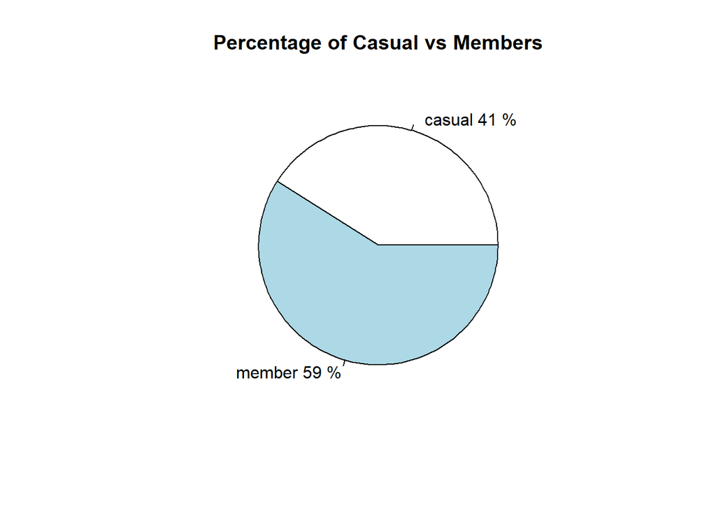

```r
pie(totalrides$n, main = "Percentage of Casual vs Members", labels = paste(" ", totalrides$member_casual, sep = " ",pct, "%"))
```

### Find the Mean, Median, Max and Min of all ride lengths

```r
summary(all_rides_v2$ride_length)
```

```
##    Min. 1st Qu.  Median    Mean 3rd Qu.    Max.
##       1     476     874    1677    1601 3523202
```

### Compare members to casual

```r
aggregate(all_rides_v2$ride_length ~ all_rides_v2$member_casual, FUN = mean)
```

```
##   all_rides_v2$member_casual all_rides_v2$ride_length
## 1                     casual                2698.4785
## 2                     member                 967.0123
```

```r
aggregate(all_rides_v2$ride_length ~ all_rides_v2$member_casual, FUN = median)
```

```
##   all_rides_v2$member_casual all_rides_v2$ride_length
## 1                     casual                     1273
## 2                     member                      689
```

```r
aggregate(all_rides_v2$ride_length ~ all_rides_v2$member_casual, FUN = max)
```

```
##   all_rides_v2$member_casual all_rides_v2$ride_length
## 1                     casual                  3341033
## 2                     member                  3523202
```

```r
aggregate(all_rides_v2$ride_length ~ all_rides_v2$member_casual, FUN = min)
```

```
##   all_rides_v2$member_casual all_rides_v2$ride_length
## 1                     casual                        1
## 2                     member                        1
```

### Average ride time by each day for members vs casual users

```r
aggregate(all_rides_v2$ride_length ~ all_rides_v2$member_casual + all_rides_v2$day_of_week, FUN = mean)
```

```
##    all_rides_v2$member_casual all_rides_v2$day_of_week all_rides_v2$ride_length
## 1                      casual                   Friday                2566.3872
## 2                      member                   Friday                 948.2213
## 3                      casual                   Monday                2698.8843
## 4                      member                   Monday                 920.3126
## 5                      casual                 Saturday                2817.5686
## 6                      member                 Saturday                1067.7615
## 7                      casual                   Sunday                3044.9107
## 8                      member                   Sunday                1093.1743
## 9                      casual                 Thursday                2578.5452
## 10                     member                 Thursday                 912.6536
## 11                     casual                  Tuesday                2429.4913
## 12                     member                  Tuesday                 907.9542
## 13                     casual                Wednesday                2419.1462
## 14                     member                Wednesday                 918.9792
```

### Lets put the days in order

```r
all_rides_v2$day_of_week <- ordered(all_rides_v2$day_of_week, levels=c("Monday", "Tuesday", "Wednesday","Thursday", "Friday", "Saturday", "Sunday"))
```

### Average ride time by each day for members vs casual users again

```r
aggregate(all_rides_v2$ride_length ~ all_rides_v2$member_casual + all_rides_v2$day_of_week, FUN = mean)
```

```
##    all_rides_v2$member_casual all_rides_v2$day_of_week all_rides_v2$ride_length
## 1                      casual                   Monday                2698.8843
## 2                      member                   Monday                 920.3126
## 3                      casual                  Tuesday                2429.4913
## 4                      member                  Tuesday                 907.9542
## 5                      casual                Wednesday                2419.1462
## 6                      member                Wednesday                 918.9792
## 7                      casual                 Thursday                2578.5452
## 8                      member                 Thursday                 912.6536
## 9                      casual                   Friday                2566.3872
## 10                     member                   Friday                 948.2213
## 11                     casual                 Saturday                2817.5686
## 12                     member                 Saturday                1067.7615
## 13                     casual                   Sunday                3044.9107
## 14                     member                   Sunday                1093.1743
```

### Analyze ride data by type and weekday

```r
all_rides_v2 %>%
  mutate(weekday = wday(started_at, label = TRUE)) %>% #creates weekday field using wday()
  group_by(member_casual, weekday) %>% #groups by usertype and weekday
  summarise(number_of_rides = n(), average_duration = mean(ride_length)) %>% # calculates the average duration and number of rides
  arrange(member_casual,)
```

```
## # A tibble: 14 x 4
## # Groups:   member_casual [2]
##    member_casual weekday number_of_rides average_duration
##    <chr>         <ord>             <int>            <dbl>
##  1 casual        Sun              262243            3045.
##  2 casual        Mon              151151            2699.
##  3 casual        Tue              145252            2429.
##  4 casual        Wed              158382            2419.
##  5 casual        Thu              166375            2579.
##  6 casual        Fri              208522            2566.
##  7 casual        Sat              335034            2818.
##  8 member        Sun              265270            1093.
##  9 member        Mon              267311             920.
## 10 member        Tue              284336             908.
## 11 member        Wed              305069             919.
## 12 member        Thu              300426             913.
## 13 member        Fri              306363             948.
## 14 member        Sat              323076            1068.
```

# Let’s visualize our data using Ride Length by Member/Casual

### Per day of the week

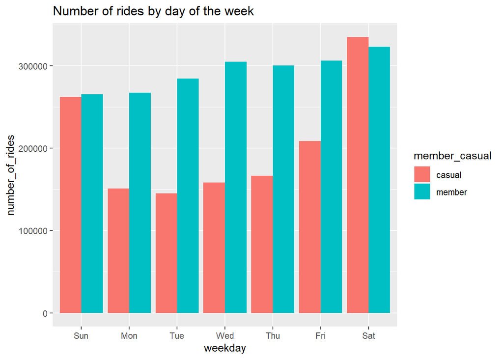

```r
all_rides_v2 %>%
  mutate(weekday = wday(started_at, label = TRUE)) %>%
  group_by(member_casual, weekday) %>%
  summarise(number_of_rides = n(), average_duration = mean(ride_length)) %>%
  arrange(member_casual, weekday) %>%
  ggplot(aes(x = weekday, y = number_of_rides, fill = member_casual)) + geom_col(position = "dodge") + labs(title = "Number of rides by day of the week")
```

### Per month

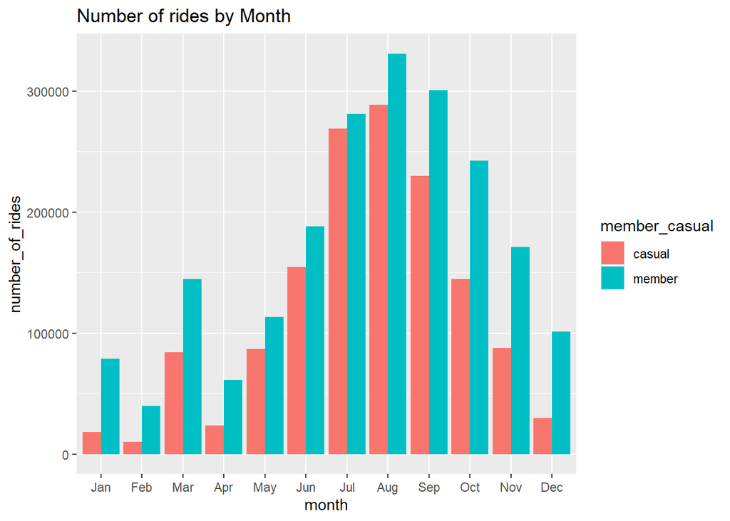

```r
all_rides_v2 %>%
  mutate(month = month(started_at, label = TRUE)) %>%
  group_by(month,member_casual) %>%
  summarise(number_of_rides = n()
            ,average_duration = mean(ride_length)) %>%
  arrange(month, member_casual) %>%
  ggplot(aes(x = month, y = number_of_rides, fill = member_casual)) + geom_col(position = "dodge") + labs(title = "Number of rides by Month")
```

### Average duration

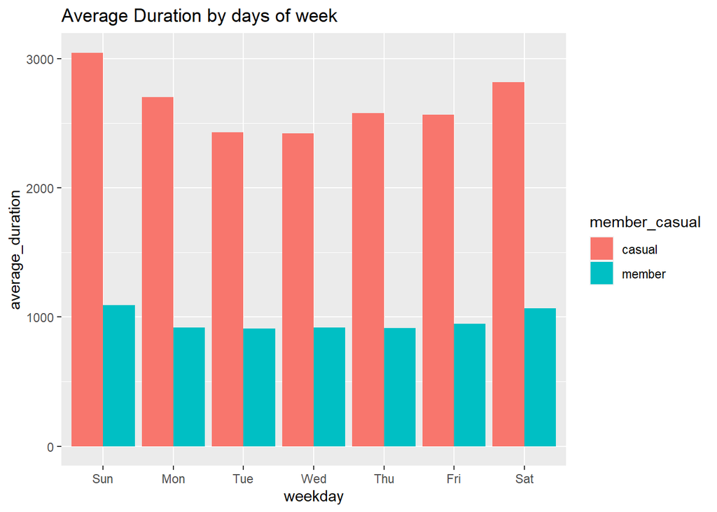

```r
all_rides_v2 %>%
  mutate(weekday = wday(started_at, label = TRUE)) %>%
  group_by(member_casual, weekday) %>%
  summarise(number_of_rides =n(), average_duration = mean(ride_length)) %>%
  arrange(member_casual, weekday) %>%
  ggplot(aes(x = weekday, y = average_duration, fill = member_casual)) + geom_col(position = "dodge") + labs(title = "Average Duration by days of week")
```

# EXPORT SUMMARY FILE FOR FURTHER ANALYSIS

### Summary of weekday rides

```r
summary_wd <- all_rides_v2 %>%
  mutate(weekday = wday(started_at, label = TRUE)) %>%
  group_by(member_casual, weekday) %>%
  summarise(number_of_rides =n(), average_duration = mean(ride_length)) %>%
  arrange(member_casual, weekday)
```

```r
write.csv(summary_wd, "summary_of_ridelengths_weekday.csv")
```

### Summary of month rides

```r
summary_month <- all_rides_v2 %>%
  mutate(month = month(started_at, label = TRUE)) %>%
  group_by(member_casual, month) %>%
  summarise(number_of_rides =n(), average_duration = mean(ride_length)) %>%
  arrange(member_casual, month)
```

```r
write.csv(summary_month, "summary_of_ridelengths_month.csv")
```

### Summary of stations

```r
summary_station <- all_rides_v2 %>%
  mutate(station = start_station_name) %>%
  drop_na(start_station_name) %>%
  group_by(member_casual, start_station_name) %>%
  summarise(number_of_rides =n()) %>%
  arrange(number_of_rides)
```

```r
write.csv(summary_station, "summary_of_numberofrides_station.csv")
```